# Prediction in Sentiment Analysis - Amazon Sample

Results - Insights - Methodology

Philippe Lambot

April 14, 2020

## *********************************************************************************

## PREDICTION IN SENTIMENT ANALYSIS - AMAZON SAMPLE

## *********************************************************************************

## I. EXECUTIVE SUMMARY

**Natural Language Processing** has contributed 21.7 percentage points: corpus, lowercasing, punctuation handling, stopword removal, stemming, tokenization from sentences into words, bag of words.

TAGS: sentiment analysis, natural language processing, text mining, subjective information, tokenization, bag of words, word frequency, wordclouds, decision trees, false negatives, false positives, text classification, polarization, lists of positive n-grams, lists of negative n-grams, text substitution, machine learning, binary classification, eXtreme Gradient Boosting, Monotone Multi-Layer Perceptron Neural Network, Random Forest, Stochastic Gradient Boosting, Support Vector Machines with Radial Basis Function Kernel, AdaBoost Classification Trees, bootstrapping, accuracy distributions across resamples, R

GITHUB: https://github.com/Dev-P-L/Sentiment-Analysis

## II. FOREWORD to READERS

Dear Readers, you are most welcome to run the project on your own computer if you so wish.

This project is lodged with the GitHub repository https://github.com/Dev-P-L/Sentiment-Analysis.

It is comprised of twelve files. All code is included in SA_Amazon_Code.Rmd. It does not show in the result report, called SA_Amazon_Insights&Results.html.

For your convenience, the dataset has already been downloaded onto the GitHub repository wherefrom it will be automatically retrieved by the code from SA_Amazon_Code.Rmd. If you so wish, you can also easily retrieve the dataset from https://archive.ics.uci.edu/ml/datasets/Sentiment+Labelled+Sentences and adapt the SA_Amazon_Code.Rmd code accordingly.

You can knit SA_Amazon_Code.Rmd (please in HTML) and produce SA_Amazon_Insights&Results.html on your own computer. On my laptop, running SA_Amazon_Code.Rmd takes approximately four hours. For information, here are some characteristics of my work environment:

- R Version 4.0.3 (2020-10-10) – “Bunny-Wunnies Freak Out”,
- RStudio Version 1.3.1093 (2020-09-17) – “Apricot Nasturtium”,
- Windows 10.

Some packages are required in SA_Amazon_Code.Rmd. The code from SA_Amazon_Code.Rmd contains instructions to download these packages if they are not available yet.

Now, let’s get in touch with data.

## III. GETTING IN TOUCH with DATA

As explained on the UCI Machine Learning Repository website, data is organized in a CSV file in two columns. In the first column, there are 1,000 Amazon product reviews (sentences). In the second column, there is a positive or negative evaluation; the ratio of positive evaluations is 50 %.

That file will be split into training reviews - two thirds of reviews - and validation reviews. Let’s have a quick look at a few training reviews.

|  | ILLUSTRATIVE SAMPLE OF TRAINING REVIEWS | SENTIMENT |
| --- | --- | --- |
| 265 | THAT one didn’t work either. | Neg |
| 388 | The best phone in market :). | Pos |
| 502 | This battery is an excellent bargain! | Pos |
| 558 | I have purchased these for both family and friends, and all enjoy their clarity and ease of use | Pos |
| 803 | Great price, too! | Pos |
| 833 | dont buy it. | Neg |
| 856 | Just does not work. | Neg |
| 896 | It was quite comfortable in the ear. | Pos |
| 937 | I kept catching the cable on the seat and I had to pull the phone out to turn it on an off. | Neg |
| 958 | Love it.. Great armband. | Pos |
| 994 | disappointed. | Neg |
| 996 | The screen does get smudged easily because it touches your ear and face. | Neg |

Let’s proceed to some NLP.

## IV. NATURAL LANGUAGE PROCESSING

### A. Corpus - Tokenization - Bag of Words

Training reviews will be transposed into a corpus. Then the corpus will be processed in NLP: words will be lowercased, punctuation marks will be removed as well as stopwords and finally words will be stemmed.

Tokenization will then take place, a bag of words being created. The bag of words takes the form of a Document Term Matrix: the 668 rows correspond to the 668 training reviews; there is a column for each token. At the junction of each row and each column, there is a frequency number representing the occurrence of the corresponding token in the corresponding review.

Applying a sparsity threshold of .995 will only leave tokens that appear in at least 0.5 % of reviews.

As a pre-attentive insight, a wordcloud will show the most frequent tokens. The wordcloud is interactive: just hover over a token and you get the frequency of occurrence.

[interactive chart not shown]

There are topic-related tokens such as “phone”, tokens conveying subjective information such as “great”, etc. Before analyzing token categories, let’s check up the technical adequacy of results from the NLP process.

### B. Checking up NLP Output

Some tokens were not expected, such as “dont” or “ive”, since they seem to originate in short forms and were expected to have been eliminated as stopwords. Let’s start investigating with “dont”. How many rows contain " dont "?

|  | # REVIEWS CONTAINING “dont” |
| --- | --- |
| Bag of Words from Training Reviews | 20 |

Perusing training set reviews containing “dont” has led to distinguishing two scenarios. The first one is an exception, but it can be generalized to other tokens. Here it is.

|  | REVIEW GENERATING “dont” IN CORPUS |
| --- | --- |
| Set of Training Reviews | dont buy it. |

“dont” contains a spelling error or is “alternative” grammar. Nevertheless, ideally, it should be treated as a short form from standard grammar, i.e. as the short form “don’t”. Consequently, if we want to eradicate short forms as being stopwords, we’ll have to complement stopwords with variants such as “dont”, “couldnt”. This will be done in the next section “C. Fine Tuning NLP”.

Now, let’s have a look at the most common scenario that has generates “dont”.

|  | REVIEW GENERATING “dont” IN CORPUS |
| --- | --- |
| Set of Training Reviews | Don’t buy this product. |

This is another scenario: “don’t” has been written in a standard way, but all punctuation marks have been removed, consequently it has become “dont” and is no longer identical to the stopword “don’t” and, very logically, it has not been removed.

This will be corrected not just for this instance but because it is systemic (you only have to change the system and not to correct manually) and systematic (it could happen several or even many times).

Consequently, short forms should be removed before removing punctuation. Or punctuation marks should be removed except for apostrophes before removing short forms. An appropriate solution will be applied in the next section “C. Fine Tuning NLP”.

While examining other tokens coming from training reviews, other oddities have been discovered. There are several unigrams that seem to originate from two words, e.g. “brokeni” at row 24 of all tokens sorted alphabetically (i.e. all tokens before applying the sparsity process described above).

| 24 | breakag | brilliant | broke | brokeni | brows |
| --- | --- | --- | --- | --- | --- |

Which training review does “brokeni” come from?

|  | REVIEW PRODUCING “brokeni” |
| --- | --- |
| Set of Training Reviews | I got the car charger and not even after a week the charger was broken…I went to plug it in and it started smoking. |

What happened? Well, “broken…I” was first lowercased to “broken…i”, then punctuation was removed by the function removePunctuation(), which does not insert any white space character, and “broken…i” has become “brokeni”.

This has to be corrected of course for “brokeni” but also for similar cases. In the next section “C. Fine Tuning NLP”, a general solution will be applied.

### C. Fine Tuning NLP

Instead of the function removePunctuation() from the package tm, specific for loops will be developed, preprocessing reviews according to the needs stated above and in a stepwise way:

- punctuation marks other than apostrophes will be replaced with white space characters instead of just being removed;
- short forms will be removed;
- remaining apostrophes will be replaced with white space characters;
- other stopwords will be removed (it is done in step 4 and not in step 2 in order to do it when absolutely all punctuation marks have been removed: please see example with “brokeni” where two words and one punctuation mark are stuck together…).

Among stopwords, short forms (contractions) need to be specifically treated. Additional needs of breakdown might also emerge. Starting from the stopword list delivered by the function stopwords(“english”) from the package tm, four CSV files will be produced.

These are the four files:

- short_forms_pos.csv, with all positive short forms from stopwords(“english”) such as “she’s”, a few additional ones and numerous misspelled variants such as “she s” or “shes”;
- short_forms_neg.csv, in the same approach, for short forms such as “isn’t”, “daren’t” but also “isn t”, “isnt”, etc.;
- negation.csv, with seven negational unigrams such as “not” or “no”;
- stopwords_remaining.csv, which is self-explanatory.

The 4 files have been uploaded to the GitHub repository https://github.com/Dev-P-L/Sentiment-Analysis. They are going to be downloaded now and integrated into NLP pre-processing.

Let’s rebuild the corpus, the bag of words and the interactive wordcloud (just hover over token to get the frequency of occurrence).

[interactive chart not shown]

In the wordcloud, there is no more token originating from short forms. Let’s have a broader look, building up a presentation table and checking whether abovementioned oddities have disappeared. Let’s check up in the bag of words whether “dont” has indeed disappeared.

| 51 | dit | dock | done | doubl | download |
| --- | --- | --- | --- | --- | --- |

Yes, indeed, “dont” has disappeared. Let’s check up in the same way for “ive”!

| 96 | issu | item | jabra | jawbon | jerk |
| --- | --- | --- | --- | --- | --- |

“ive” has also disappeared. Now “brokeni”.

| 21 | breakag | brilliant | broke | broken | brows |
| --- | --- | --- | --- | --- | --- |

“brokeni” has vanished as well, just as many other oddities. I leave uncorrected some spelling errors, such as “disapoint” or “dissapoint”, because this is no repetitive structure and occurrence seems marginal.

Let’s have a first try at predicting sentiment on the basis of sentSparse_av0, which is our training set.

### D. Measuring NLP Impact on Prediction Accuracy

The chosen machine learning model will be CART: it runs rather quickly and delivers clear decision trees. Running function rpart() on the training set delivers the accuracy level mentioned hereunder.

|  | ACCURACY ON THE TRAINING SET |
| --- | --- |
| Model: CART | 0.768 |

Now let’s train the rpart method with the train() function from the package caret.

By default, the train() function would train across 3 values of cp (the complexity parameter) and 25 bootstrapped resamples for each tuned value of cp. As far as the number of tuned values is concerned, let’s upgrade it to 15 to increase the odds of improving accuracy, especially as rpart runs rather quickly.

The default resampling method is bootstrapping, samples being built with replacement, some reviews being picked up twice or more and some other reviews not being selected. This method seems especially appropriate here because the size of each resample will be the same of the size of the training set, which is already limited, i.e. 668. Working with e.g. K-fold cross-validation would imply further splitting the training set.

Will accuracy improve?

|  | ACCURACY ON THE TRAINING SET |
| --- | --- |
| Model: CART + cp Tuning | 0.7814 |

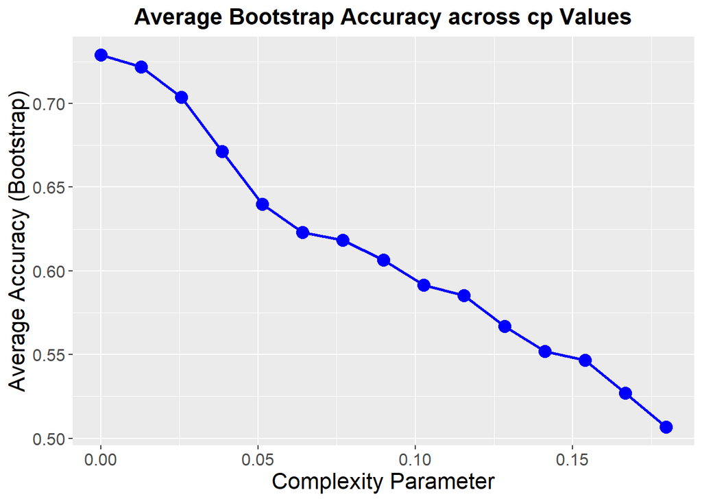

On the graph above, maximum accuracy is a bit lower than the level previously indicated. Why is it different? Because, on the graph, it is, for each cp value, the average accuracy on the 25 bootstrapped resamples, while accuracy previously given related to the whole training set.

The optimal value of cp is near zero. Is it really zero?

|  | OPTIMAL cp VALUE |
| --- | --- |
| Model: CART + cp Tuning | 0.0000 |

Yes, it is zero. This means that the train() function has kept the decision tree as complex as possible by assigning a zero value to the complexity parameter.

|  | ACCURACY ON THE TRAINING SET |
| --- | --- |
| Model: Baseline | 0.5000 |

Let’s summarize results from the three models, not only with accuracy but also with additional performance metrics.

| MODEL ID | SHORT DESCRIPTION | ACCURACY | SENSITIVITY | NEG PRED VAL | SPECIFICITY | POS PRED VAL |
| --- | --- | --- | --- | --- | --- | --- |
| baseline | baseline model | 0.5000 | 1.0000 | Div. by 0 | 0.0000 | 0.5000 |
| cart_av0 | CART | 0.7680 | 0.6407 | 0.7136 | 0.8952 | 0.8594 |
| cart_tuned_av0 | CART + tuning | 0.7814 | 0.7066 | 0.7448 | 0.8563 | 0.8310 |

In the table above, on row 1, fonts have been stricken through to indicate that this model is discarded because if delivers only 50 % accuracy and looks like a dead-end path.

The other two models should be seen as a cumulative process bringing accuracy improvement in a stepwise and incremental way, with the one on green background being the best in accuracy. Models 2 and 3 deliver higher accuracy but also asymmetry between other performance metrics: sensitivity and negative predictive value are lower than specificity and positive predictive value. This reflects false negatives being more numerous than false positives. False negatives are predictions pointing to “Neg” while the reference value is " Pos". This is an insight for text mining: perusing false negatives and coming with actionable findings.

In order to confirm that false negatives are more numerous than false positives, let’s have a look at the confusion matrix for both models. First, the confusion matrix from the rpart model without tuning.

|  | Actually positive | Actually negative |
| --- | --- | --- |
| Predicted positive with CART | TP = 214 | FP = 35 |
| Predicted negative with CART | FN = 120 | TN = 299 |

The weak point lies in the first column, on green background: the relatively high number of false negatives and, as a corollary, the relatively low number of true positives. On the reference positive class (" Pos" in label), predicting seems problematic or at the very least challenging since false negatives are rife. On the contrary, on the reference negative class (“Neg” in label), predicting has run smoothly, with a satisfactorily low number of false positives.

The tuned rpart model is expected to slightly reduce the excess in false negatives.

|  | Actually positive | Actually negative |
| --- | --- | --- |
| Predicted positive with CART + tuning | TP = 236 | FP = 48 |
| Predicted negative with CART + tuning | FN = 98 | TN = 286 |

With the tuned rpart model, accuracy has slightly improved: the sum of numbers on the main diagonal is larger.

On the green background, predicting on the reference positive class is less prolific in false negatives and, as a corollary, true positives are more predominant. On the secondary diagonal, imbalance between false negatives and false positives is less marked, not only because there are less false negatives but also because there are more false positives. Nevertheless false negatives remain the weak point, still being twice as numerous as false positives.

False negatives - and false positives - will be perused through text mining in the next section, looking for new insights towards accuracy improvement.

## V. INSIGHTS from TEXT MINING

Let’s now have a look at the false negatives, which constitute a challenge, from the CART model with tuning.

### A. Visualizing False Negatives

|  | Review Corresponding to a FALSE NEGATIVE with CART + Tuning | After NLP | Usable Subjective Information |
| --- | --- | --- | --- |
| 1 | If you are Razr owner…you must have this! | razr owner must | super |
| 2 | This phone is very fast with sending any kind of messages and web browsing is significantly faster than previous phones i have used. | phone fast send kind messag web brows signific faster previous phone use | fast + faster |
| 3 | I got it because it was so small and adorable. | got small ador | prettier + sharp |
| 4 | Jawbone Era is awesome too! | jawbon era awesom | infatu |
| 5 | You won’t regret it! | regret | wise |
| 6 | The phone is sturdy and waterproof. | phone sturdi waterproof | awesom |
| 7 | Virgin Wireless rocks and so does this cheap little phone! | virgin wireless rock cheap littl phone | rock |
| 8 | Very wind-resistant. | wind resist | [no trouble] |
| 9 | This case has passed the one year mark and while it shows signs of wear, it is 100% functional. | case pass one year mark show sign wear function | [knows what they’re doing] |
| 10 | It was that loud.Glad to say that the Plantronics 510 maintains a flawless connection to my cell and with no static during normal use. | loud glad say plantron maintain flawless connect cell static normal use | [as described] |
| 11 | Leopard Print is wonderfully wild!. | leopard print wonder wild | secur |
| 12 | cool phone. | cool phone | quick |

There are three scenarios, each illustrated on a different background color. Let’s get started with the first scenario on the blue background.

### B. Subjective Information Unigrams

On the blue background in the table above, there are 9 cases out of 12. In each of these 9 reviews, there is at least one token with subjective information that is clear from a human point of view. Let’s just pinpoint “super”, “fast”, “faster”, “prettier”, “infatuated”, “wise”, “awesome”, “rocks”, etc., or, after stemming “super”, “fast”, “faster”, “prettier”, “infatu”, “wise”, “awesom”, “rock”, etc.

These words, and the related standardized tokens, can be classified in two categories:

- compliance-related tokens, expressing compliance or incompliance with expectations, requirements or advertisements (“super”, “faster”, “rocks”, etc.),
- sentiment-related tokens other than in previous category (“infatuated”).

The difference between the two categories can sometimes be tricky and both categories will be referred to altogether in this project using phrases such as “subjective information” or “tokens conveying subjective information”.

“Unfortunately”, the tokens pinpointed among the false negatives do not show in the decision trees. Let’s visualize the decision tree from the CART model with tuning.

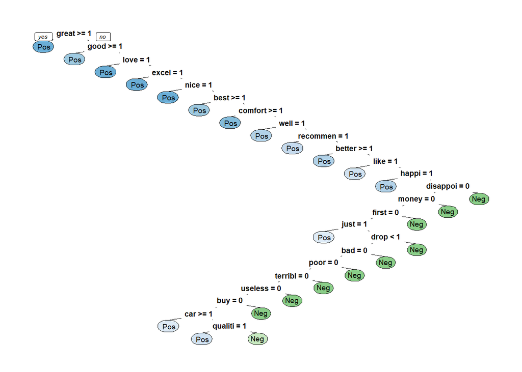

What types of tokens can be seen in the decision tree?

There is a majority of tokens conveying subjective information (“great”, “comfort”, “love”, “like”, “disappoi”, etc.). They are usually the highest ranked.

Which is an interesting insight. In CART, tokens conveying subjective information predominate, which is not at all surprising! This points to solutions allocating higher priority to tokens conveying subjective information.

Although a majority of tokens are conveying subjective information in the decision tree, we do not find the many tokens with subjective information pinpointed among false negatives. It is probably a matter of word (or token) frequency. This can be first checked up in the wordcloud that has already been visualized.

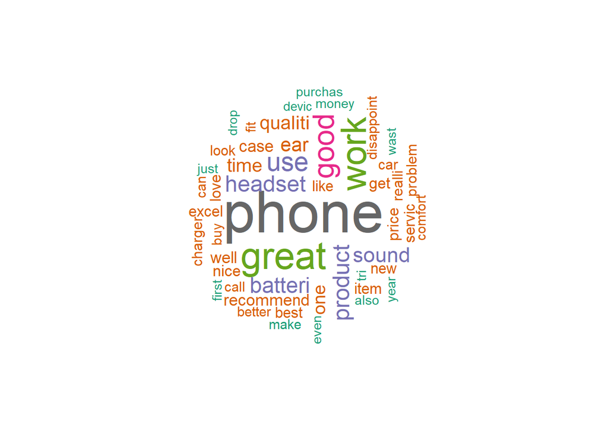

The wordcloud, which requires a minimal frequency of 10, is not comprised of the tokens with subjective information pinpointed among the false negatives.

“phone”, which is topic-related, is the token with the highest frequency. Other topic-related tokens rank among the highest frequencies: “batteri”, “product”, “headset”, “sound”, etc.

“phone” has the highest frequency in the wordcloud but does not show in the decision tree. The same holds for other highly ranked topic-related tokens.

For illustrative purposes, tokens can be visualized in decreasing order of frequency in the graph below.

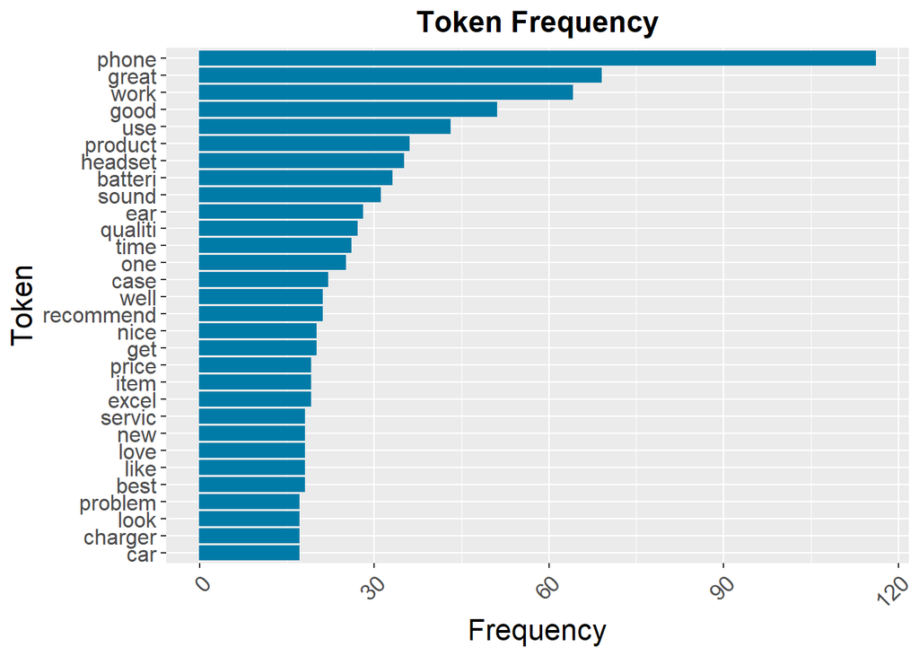

This looks like an interesting insight. Token frequency should not be the only criterion. Actually, there should be some hierarchy between types of tokens (subjective information, intent-related, topic-related). This does not necessarily mean a strict hierarchy between categories at a first level and then between tokens at a second level; there could be some intermixture, token frequency could coexist with prioritization of subjective information.

In conclusion, it might be impactful to garner subjective information conveyed by tokens such as “super”, “prettier”, “infatu”, “awesom”, etc. Since CART doesn’t do it, why not replace such tokens with a generic token either positive or negative? This would empower subjective information by building high frequency generic tokens only typified by sentiment orientation.

In this project, polarity of some tokens conveying subjective information will be inserted in additional files. That is one avenue of improvement that will be investigated in VI. INFORMATION RETRIEVAL thanks to INSIGHTS.

### C. Negation Handling

Let’s go back to the table above that is comprised of 12 reviews corresponding to false negatives from the model cart_tuned. More particularly, let’s retrieve the review with a negational unigram.

|  | Review Corresponding to a FALSE NEGATIVE with CART + Tuning | After NLP | Usable Subjective Information |
| --- | --- | --- | --- |
| 8 | Very wind-resistant. | wind resist | [no trouble] |

The bigram “no trouble” is clear from a human point of view but this bigram has become “troubl”, the negational token “no” having been removed with all other stopwords. Even if “troubl” is polarized under a generic negative token, as suggested above, the right polarity of “no trouble” wouldn’t show. Two avenues are opened up: the whole bigram “no trouble” could be converted into a generic token with positive orientation or, more generally, negational stopwords such as “not” or “no” could no longer be removed, which is another avenue for improvement.

In this sample, there is only one case out of 12 with an ignored negational phrase. Is it worthwhile heading for properly dealing with negational unigrams? Let’s integrate negational unigrams into the bag of words and produce a wordcloud in order to get some pre-attentive insight about frequency of negational unigrams such as “not” or “no”.

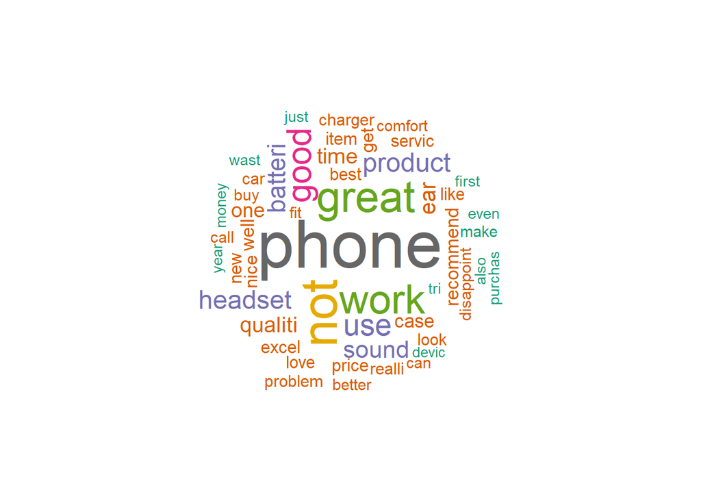

“not” appears in the wordcloud and is highly ranked, just below “phone”. This is an insight advocating inclusion of negational unigrams.

Let’s have a look at word associations with “not”: does “not” often reverse review polarity?

| Token | Correlation with “not” |
| --- | --- |
| impress | 0.18 |
| anyon | 0.17 |
| enough | 0.15 |
| item | 0.15 |
| will | 0.11 |
| make | 0.10 |
| never | 0.10 |
| buy | 0.09 |
| motorola | 0.09 |
| connect | 0.08 |
| drop | 0.08 |
| find | 0.08 |
| nokia | 0.08 |
| place | 0.08 |
| side | 0.08 |
| broke | 0.07 |
| care | 0.07 |
| charger | 0.07 |
| come | 0.07 |
| design | 0.07 |
| much | 0.07 |
| need | 0.07 |
| pair | 0.07 |
| talk | 0.07 |
| think | 0.07 |
| unit | 0.07 |
| went | 0.07 |
| fit | 0.06 |
| plug | 0.06 |
| time | 0.06 |

On the list, the first stemmed unigram associated with “not” is “impress”. Let’s localize the reviews producing “impress” to get an idea of frequency.

|  | Training Review Containing “impressed” |
| --- | --- |
| 1 | Not impressed. |
| 2 | great headset, very impressed - H500. |
| 3 | I am very impressed with this headset from Plantronics. |
| 4 | I am very impressed with the job that Motorola did on the sturdiness of this phone. |
| 5 | I am not impressed with this and i would not recommend this item to anyone. |
| 6 | All it took was one drop from about 6 inches above the kitchen counter and it was cracked.I am not impressed and I am not laughing. |
| 7 | I was very impressed with the price of the cases. |

In the three training reviews on green background, there are three reviews containing “not impressed”. Moreover, in the second of these reviews, there is also “not recommend” and in the third “not laughing”. This is an additional illustration of the usefulness of including negational unigrams in one way or another. It will be given a try in VI. INFORMATION RETRIEVAL thanks to INSIGHTS.

Up to now, negation has been shown in negational unigrams but negation can also be encapsulated into short forms (also called “contractions”). The previous sample of false negatives, which has been selected at random, is not comprised of negative short forms. But the same random procedure, applied to false positives, delivers several of them.

|  | Review Corresponding to a FALSE POSITIVE with CART + Tuning | After NLP | Usable Subjective Information |
| --- | --- | --- | --- |
| 1 | The design is very odd, as the ear “clip” is not very comfortable at all. | design odd ear clip comfort | not a good |
| 2 | This item worked great, but it broke after 6 months of use. | item work great broke month use | whine + ? the less |
| 3 | If you like a loud buzzing to override all your conversations, then this phone is for you! | like loud buzz overrid convers phone | shouldn’t |
| 4 | I wouldn’t recommend buying this product. | recommend buy product | slow + crawl + lock-up |
| 5 | Excellent starter wireless headset. | excel starter wireless headset | did not work well |
| 6 | Not good when wearing a hat or sunglasses. | good wear hat sunglass | still waiting |
| 7 | The sound quality for the device is unacceptable.Unless you are in a really quiet area, you almost hear nothing. | sound qualiti devic unaccept unless realli quiet area almost hear | terrible |
| 8 | i would advise to not purchase this item it never worked very well. | advis purchas item work well | difficult |
| 9 | So just beware. | just bewar | wasn’t always easy |
| 10 | I tried talking real loud but shouting on the telephone gets old and I was still told it wasn’t great. | tri talk real loud shout telephon get old still told great | sorry |
| 11 | The speaker is of low quality so as making the ring tones sound very cheap. | speaker low qualiti make ring tone sound cheap | not as good |
| 12 | however, my girl was complain that some time the phone doesn’t wake up like normal phone does. | howev girl complain time phone wake like normal phone | don’t like |

In the table above, there are seven negation forms, which machine learning could not take into account since these negation forms had been removed through NLP. So, “Not a good bargain.” has become “good bargain” and “don’t like” has mutated into “like”!

On the blue background, “not” comes thrice in three training reviews.

This shows the importance of negation, be it under the form of negational unigrams (“not”, etc.) or under the form of negational short forms.

In the table above, interpretation of some training reviews is rather complex. They will be analyzed in the next section, as well as other complex reviews shown before.

### D. Subjective Information Multigrams

Sentiment can also be expressed through associations of words beyond negation cases already treated.

In some cases, these are rather stereotyped phrases. Let’s go back to two examples already provided by false negatives.

|  | Review Corresponding to a FALSE NEGATIVE with CART + Tuning | After NLP | Usable Subjective Information |
| --- | --- | --- | --- |
| 9 | This case has passed the one year mark and while it shows signs of wear, it is 100% functional. | case pass one year mark show sign wear function | [knows what they’re doing] |
| 10 | It was that loud.Glad to say that the Plantronics 510 maintains a flawless connection to my cell and with no static during normal use. | loud glad say plantron maintain flawless connect cell static normal use | [as described] |

In the table above, there are two rather stereotyped phrases with usable information: “knows what they’re doing” (competency statement) or “as described” (compliance statement). Some of these phrases will be listed (with spelling variants) among positive multigrams and instances of them in reviews will be replaced with a generic token with positive orientation.

False positives have delivered some more difficult cases: reviews with figurative wording, sarcasm, irony, metaphors, multifaceted reviews, etc.

|  | Review Corresponding to a FALSE POSITIVE with CART + Tuning | After NLP | Usable Subjective Information |
| --- | --- | --- | --- |
| 2 | This item worked great, but it broke after 6 months of use. | item work great broke month use | whine + ? the less |
| 3 | If you like a loud buzzing to override all your conversations, then this phone is for you! | like loud buzz overrid convers phone | shouldn’t |
| 4 | I wouldn’t recommend buying this product. | recommend buy product | slow + crawl + lock-up |
| 7 | The sound quality for the device is unacceptable.Unless you are in a really quiet area, you almost hear nothing. | sound qualiti devic unaccept unless realli quiet area almost hear | terrible |

The table above gives four examples of more complex wording:

- figurative word such as “whine” instead of e.g. “disappointed”;
- figurative word such as “crawl”;
- sarcasm and metaphors about “monkeys”;
- multifaceted review such as “My experience was terrible….. This was my fourth bluetooth headset, and while it was much more comfortable than my last Jabra (which I HATED!!!”.

What will be done here: listing some unigrams or multigrams such as “whine”, “shouldn’t”, “lock up” as negatively oriented and replacing instances of them in training reviews with one generic negative token.

### E. Topic-related Tokens

It has been seen that some topic-related tokens have high frequency but do not appear in the decision tree. So, “phone” has the highest frequency but is not present in the decision tree. “batteri”, “headset” do not even appear in the decision tree either.

This difference between wordcloud and decision tree might be insightful. Should topic-related tokens be discarded except the few ones that appear in the decision tree? Should they be excluded to make the bag of words less messy? But would they systematically be excluded as well in other machine learning models?

To get some confirmation or infirmation, let’s apply another algorithm. A Random Forest model is chosen because it allows for some rough ranking of predictor impact. Here is the accuracy level on the training set.

|  | ACCURACY ON THE TRAINING SET |
| --- | --- |
| Model: Random Forest | 0.9581 |

Would the high accuracy level mean that this model solves all issues and that further text mining and further machine learning are both useless? I do not think so: very often, at least on the basis of my experience, rf has a tendency to overfitting. Results on the validation set might be substantially lower. Consequently, text mining remains meaningful and worth performing.

Let’s check whether topic-related tokens that do not show in the CART decision tree are positioned at a relatively high level in the predictor importance list from Random Forest.

| Stemmed Token | Predictor Importance in Random Forest |
| --- | --- |
| great | 100.00 |
| good | 50.76 |
| love | 38.92 |
| excel | 34.98 |
| nice | 30.37 |
| best | 27.57 |
| comfort | 20.00 |
| well | 19.63 |
| recommend | 19.60 |
| phone | 16.72 |
| fine | 15.54 |
| better | 14.56 |
| easi | 13.91 |
| order | 13.82 |
| sturdi | 13.55 |
| perfect | 13.03 |
| like | 12.72 |
| disappoint | 12.04 |
| happi | 8.97 |
| headset | 8.90 |

Consequently, topic-related tokens that do not show in the CART decision tree will not be discarded.

By the way, Random Forest has outperformed CART in accuracy but there are false negatives and positives with Random Forest as well, even if less numerous. Here is the confusion matrix from Random Forest.

|  | Actually positive | Actually negative |
| --- | --- | --- |
| Predicted positive with Random Forest | 312 | 6 |
| Predicted negative with random Forest | 22 | 328 |

As expected, the number of false negatives and false positives is more limited than with CART since accuracy is larger. It is also true for each group separately: less false negatives in Random Forest and less false positives.

Let’s have a look at the false negatives, which are more numerous. Here is a sample of the false negatives from Random Forest.

| Review Corresponding to a FALSE NEGATIVE with Random Forest | After NLP | Usable Subjective Information |
| --- | --- | --- |
| If you are Razr owner…you must have this! | razr owner must | simpler |
| It has been a winner for us. | winner us | job done |
| )Setup couldn’t have been simpler. | setup simpler | incred |
| Someone shouldve invented this sooner. | someon shouldv invent sooner | shouldv invent sooner |
| Very pleased with this headset. | pleas headset | rock |
| Portable and it works. | portabl work | incredi |
| This fixes all the problems. | fix problem | fix problem |
| These are fabulous! | fabul | fabul |
| Because both ears are occupied, background is not distracting at all. | ear occupi background distract | perfect |
| Works for me. | work | thumbs up |
| It is a joy to use. | joy use | any problem |
| Very satisifed with that. | satisif | wonder |

On the blue background, there are training reviews with usable stemmed unigrams indicating positive polarity: “fabul”, “perfect”, etc.

On the green background, there are positively oriented multigrams such as “thumbs up”.

This supports previous insights.

### F. Conclusion on Text Mining Insights

In text mining, insights have been obtained

- by comparing token frequency in the bag of words (wordcloud and histogram) and in token lists from CART and Random Forest
- and by perusing false negatives and positives in CART and Random Forest.

Among insights, let’s mention:

- topic-related tokens predominate in the bag of words;
- topic-related tokens show in limited number and at a lower level in the CART decision tree and in the predictor importance list from Random Forest;
- subjective information tokens predominate in the CART decision list and in the predictor importance list from Random Forest;
- many subjective information tokens show in false negatives or false positives but neither in the CART decision tree nor in the predictor importance list from Random Forest (first 20 positions);
- many negational n-grams are present in reviews giving false negatives or positives and often reverse sentiment polarity of the reviews but they cannot be made actionable in machine learning since they have been removed from the bag of words as stopwords;
- these negational n-grams can be negational unigrams such as “not” or negative short forms such as “isn’t”.

In the next section, these text mining insights will be tentatively transposed into NLP and machine learning actions towards more accuracy.

Three avenues of improvement have been opened up:

- integrating negational unigrams (“not”, etc.);
- integrating negative short forms (“isn’t”, etc.);
- establishing polarized lists of subjective information tokens and replacing instances of these tokens in reviews with one generic token, either positive or negative.

Stepwise, the three avenues will be quantitatively tested.

The whole research has been performed only on training reviews without any kind of intermixture with validation reviews.

## VI. INFORMATION RETRIEVAL thanks to INSIGHTS

### A. Integrating Negational Unigrams

Negational unigrams have been introduced, NLP has be rerun as well as the CART model with tuning, which is used as a performance yardstick. Here are the results.

[output not shown]

For the record, does “not” show in the decision tree?

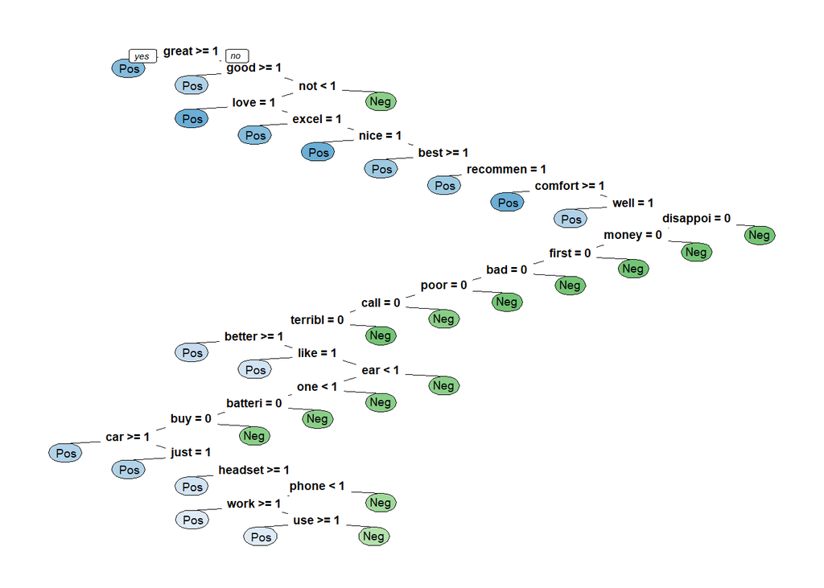

Yes, indeed it does and rather predominantly!

### B. Retrieving Information Included in Negative Short Forms

#### 1. Adding Negative Short Forms to the Bag of Words

First, negative short forms will no longer be removed from the corpus and will thus enter the bag of words. Impact on accuracy will be tested.

|  | ACCURACY ON THE TRAINING SET |
| --- | --- |
| Model: Negation + Neg Short Forms + CART + Tuning | 0.7949102 |

Adding negative short forms such as “isn’t” does not impact accuracy level. Consequently, another try will be done with negative short forms: instead of being added, negative short forms will be replaced with “not”.

#### 2. Replacing Negative Short Forms with " not "

Positive short forms will still be removed from the corpus with the function removeWords() from the package tm, which removes separate words and no substrings.

Negative short forms will be searched for with the function gsub(). To avoid picking up substrings as well, one white space character will be added in front of all negative short forms and at the end of each of them. Indeed, let’s not forget that misspelled short forms such as “dont” have been deliberately introduced as well among negative short forms to take into account “alternative grammar”, which is omnipresent in reviews. And words such as “dont” can be substrings out of other words. The gsub() function will replace the “escorted” short forms with " not ".

Let’s have a look at the new accuracy level.

|  | ACCURACY ON THE TRAINING SET |
| --- | --- |
| Model: Negation + [Neg Short Forms = “not”] + CART + Tuning | 0.7889222 |

Replacing negative short forms with " not " downgrades accuracy. This path will not be followed.

### C. Polarization - Text Classsification - Text Substitution

In samples of false negatives and false positives, analysis has pinpointed unigrams and multigrams that convey subjective information.

In the line of these insights, these n-grams have been listed and classified as positive and negative. They have been inserted into four files and the files have been uploaded in the GitHub repository https://github.com/Dev-P-L/Sentiment-Analysis :

- subj_pos_multigrams.csv,
- subj_pos_unigrams.csv,
- subj_neg_multigrams.csv,
- subj_neg_unigrams.csv.

Here are a few examples from each file of polarized n-grams.

Positive sentiment oriented unigrams from subj_pos_unigrams.csv (stemmed): “super”, “awesom”, etc.

Some positive multigrams from the file sub_pos_multigrams.csv (not stemmed): “no trouble”, “5 stars”, “thumbs up”, “it’s a ten”, “as described”, “know what they’re doing”, “must have”. Possible variants have usually been added, including variants originating from spelling errors or “alternative grammar”: “no troubles”, “not any trouble”, “not any troubles”, “no problem”, “no problems”, etc.; “five stars”, “five star”, “5-star”, “5star”, “5 star”; “it’s a 10”, “it’s a ten”, “its a 10”, etc.; “know what theyre doing”, “know what they are doing”, etc.

Some negative unigrams (after stemming) from the file subj_neg_unigrams.csv: “horribl”, “crap”, “whine”, etc.

Some negative multigrams (not stemmed) from the file sub_neg_multigrams.csv: “1 star”, “one star”, “not good”, “no good”, “shouldn’t” (often associated with negative context), “pretty piece of junk”, etc.

In the training reviews, instances of the positive n-grams will be replaced with " subjpo " and instances of negative n-grams with " subjneg ".

Efficacy-minded rules will be applied in this NLP process.

First, the polarized n-grams will be preceded and followed by one white space character when looking for instances in reviews. Otherwise, in the bag of words, the n-gram “most inconvi” would become “most in subjpo” (because “convi” is a polarized unigram in subj_pos_unigrams.csv) and then " subjpo " (because “most” and “in” are stopwords in stopwords_remaining.csv)! A negatively oriented multigram would become a positively oriented unigram! Consequently, one white space character is added in front of and at the end of each polarized n-gram before looking for matching instances in NLP-transformed reviews, in order to avoid replacing substrings.

Second, as a consequence, a white space character has to be added at the beginning and at the end of each NLP-transformed review! Otherwise, polarized n-grams, which are preceded and followed by one white space character can never match an instance that is positioned at the beginning or at the end of a review.

Third, " subjpo " and " subjneg " contain one white space character at the beginning and at the end, in order to prevent amalgamation. Indeed, what would happen if white space characters were not added? Let’s take our well known example of " conveni “: if it were replaced with just”subjpo" in the n-gram " most conveni “, then it would produce” mostsubjpo", which would no longer be a generic positive unigram! Transformation would be useless if not annoyingly counterproductive!

Fourth, multiple inter word white space characters have to be reduced to a single inter word white space character: indeed, listed multigrams only have one white space character between words and could never match multigrams from reviews with several white space characters between words.

Fifth, in training reviews, negative multigrams have got to be replaced before positive multigrams. Let’s take the example of " not a good bargain “, which is a negatively polarized multigram from the file subj_neg_multigrams.csv: if matching with instances in reviews begins with positively polarized n-grams, then” not a good bargain " in a review becomes " not a subjpo “, which might be less clear in machine learning than” subjneg "! For similar reasons, positive multigrams are matched before negative unigrams and positive unigrams.

Sixth, negative or positive polarized multigrams should be tentatively matched in decreasing order in for loops. Why? Let’s take the example of " no good bargain " in one review. In sub_neg_multigrams.csv, there are two negatively polarized multigrams: " no good bargain " and " no good “; if these are considered in decreasing order, then, in the review,” no good bargain " is replaced with " subjneg “, which looks appropriate; otherwise” no good bargain " is replaced with " subjneg bargain " and then " subjneg subjpo ": consequently, instead of having one negative generic unigram we would get one positive and one negative generic unigrams!

NLP will be rerun again. In each training review, all n-grams that match positive n-grams from subj_pos_multigrams.csv or subj_pos_unigrams.csv will be replaced with a generic positive token (" subjpo “); all n-grams that match negative n-grams from subj_neg_multigrams.csv or subj_neg_unigrams.csv will be replaced with a generic negative token (” subjneg ").

The utf8 package will be used to normalize punctuation: there has been some trouble with curly apostrophes instead of straight apostrophes.

|  | ACCURACY ON THE TRAINING SET |
| --- | --- |
| Model: Negation + Polarization + CART + Tuning | 0.8922156 |

To get some visual representation of changes, let’s have a look at a wordcloud from the new bag of words.

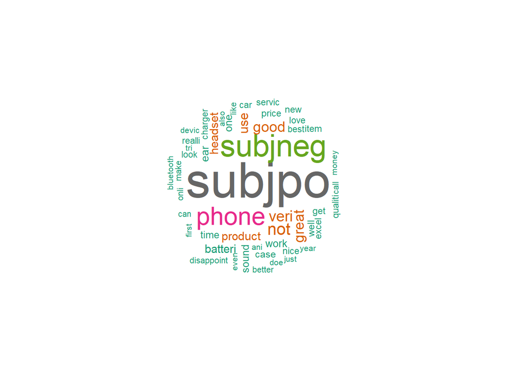

The whole picture has changed. The most frequent tokens are now “subjpo” and “subjneg”. “not” is present, at the “fourth level” (graphically).

The following histogram adds some quantitative insight.

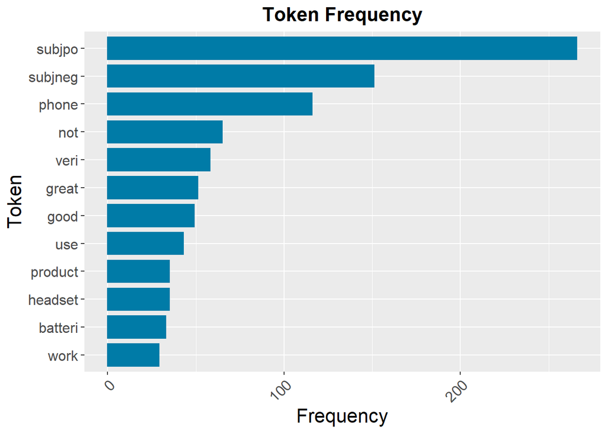

Is there any parallel evolution in the decision tree?

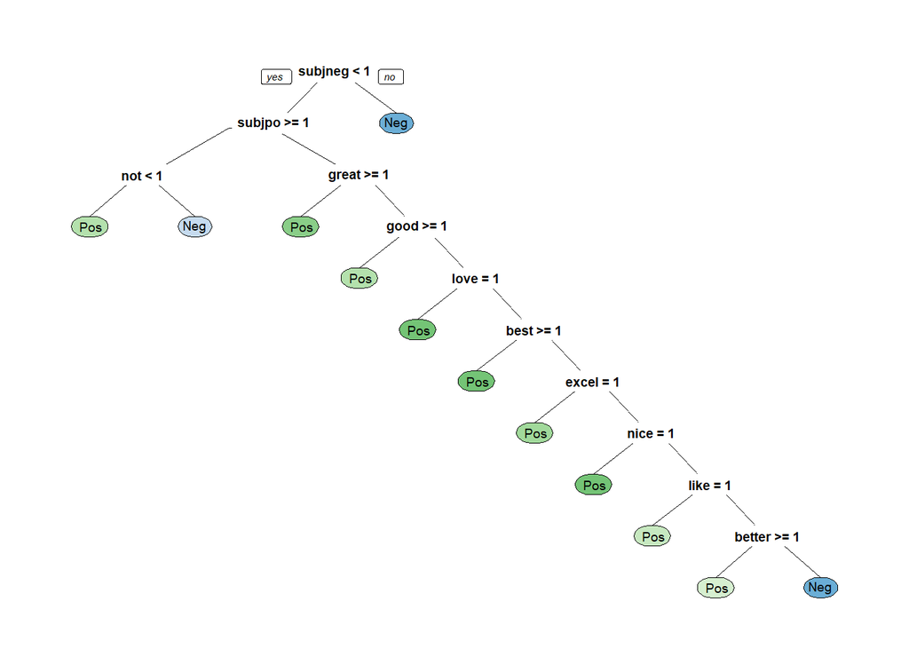

Yes, indeed there is now more parallelism between wordcloud/histogram and decision tree! The most frequent tokens in the wordcloud are now at the top of the decision tree. Indeed, the first node is occupied by “subjneg”; then comes “subjpo” and at the same level “not” and “great”. Many individual tokens that were previously in nodes of the tree, have disappeared.

The next table summarizes accuracy results obtained so far.

| MODEL ID | SHORT DESCRIPTION | ACCURACY | SENSITIVITY | NEG PRED VAL | SPECIFICITY | POS PRED VAL |
| --- | --- | --- | --- | --- | --- | --- |
| baseline | baseline model | 0.5000 | 1.0000 | Div. by 0 | 0.0000 | 0.5000 |
| cart_av0 | CART | 0.7680 | 0.6407 | 0.7136 | 0.8952 | 0.8594 |
| cart_tuned_av0 | CART + tuning | 0.7814 | 0.7066 | 0.7448 | 0.8563 | 0.8310 |
| cart_tuned_av1_a | CART + tuning + negation | 0.7949 | 0.7305 | 0.7613 | 0.8593 | 0.8385 |
| cart_tuned_av1_b | CART + tuning + negation + neg short forms | 0.7949 | 0.7305 | 0.7613 | 0.8593 | 0.8385 |
| cart_tuned_av1_c | CART + tuning + negation + neg short forms = “not” | 0.7889 | 0.7036 | 0.7468 | 0.8743 | 0.8484 |
| cart_tuned_av2 | CART + tuning + negation + polarization | 0.8922 | 0.8593 | 0.868 | 0.9251 | 0.9199 |

Let’s have a look at the numbers of remaining false negatives and positives in the following confusion matrix.

|  | Actually positive | Actually negative |
| --- | --- | --- |
| Predicted positive AFTER POLARIZING | 287 | 25 |
| Predicted negative AFTER POLARIZING | 47 | 309 |

After improving accuracy thanks to NLP and text mining, new accuracy improvements will be looked for in the next section through machine learning optimization.

## VII. MACHINE LEARNING OPTIMIZATION on the TRAINING SET

Ten models are going to be applied.

### A. 10 Machine Learning Models

Ten machine learning models have been chosen. Here is the list, with an identifier and a short description for each model.

| MODEL ID | MODEL | NAME IN CARET | # TUNING VALUES | # BOOTSTRAPPED RESAMPLES |
| --- | --- | --- | --- | --- |
| adaboost_03 | AdaBoost Classification Trees | adaboost | 3 | 25 |
| cart_03 | CART | rpart | 3 | 25 |
| gbm_03 | Stochastic Gradient Boosting | gbm | 3 | 25 |
| monmlp_03 | Monotone Multi-Layer Perceptron Neural Network | monmlp | 3 | 25 |
| rf_03 | Random Forest | rf | 3 | 25 |
| svm_03 | Support Vector Machines with Radial Basis Function Kernel | svmRadialCost | 3 | 25 |
| xgb_03 | eXtreme Gradient Boosting | xgbLinear | 3 | 25 |
| cart_15 | CART | rpart | 15 | 25 |
| gbm_15 | Stochastic Gradient Boosting | gbm | 15 | 25 |
| svm_15 | Support Vector Machines with Radial Basis Function Kernel | svmRadialCost | 15 | 25 |

All models will be trained with the train() function from the package caret.

For four models, by default, training has been done on 25 bootstrapped resamples and on 3 values of the parameters tuned. These models are “adaboost_03”, “rf_03”, “xgb_03” and “monmlp_03”. For three models that run faster on my PC, two options have been applied: either default training (“cart_03”, “svm_03” and “gbm_03) or training with tuning on 15 values across parameters tuned (”cart_15“,”svm_15" and “gbm_15”).

The names of the parameters tuned by the train() function are available in http://topepo.github.io/caret/available-models.html.

### B. Accuracy Results on the Training Set

The accuracy results are summarized in the next table.

| MODEL ID | MODEL | # TUNING VALUES | # BOOTSTRAPPED RESAMPLES | ACCURACY ON THE TRAINING SET |
| --- | --- | --- | --- | --- |
| rf_03 | Random Forest | 3 | 25 | 0.9835 |
| adaboost_03 | AdaBoost Classification Trees | 3 | 25 | 0.9820 |
| svm_15 | Support Vector Machines with Radial Basis Function Kernel | 15 | 25 | 0.9716 |
| monmlp_03 | Monotone Multi-Layer Perceptron Neural Network | 3 | 25 | 0.9701 |
| svm_03 | Support Vector Machines with Radial Basis Function Kernel | 3 | 25 | 0.9656 |
| xgb_03 | eXtreme Gradient Boosting | 3 | 25 | 0.9356 |
| gbm_03 | Stochastic Gradient Boosting | 3 | 25 | 0.8952 |
| gbm_15 | Stochastic Gradient Boosting | 15 | 25 | 0.8952 |
| cart_15 | CART | 15 | 25 | 0.8922 |
| cart_03 | CART | 3 | 25 | 0.7979 |

Not surprisingly, most models seem to overfit. As pointed out in literature, it is a rather widespread tendency, especially so with complex algorithms which have many parameters they can minimize the loss function on.

Consequently, the ranking figuring in the table above is no appropriate tool to separate models.

Accuracy cannot be tested on the validation set since the validation set is only to be used at the last step; if some testing is performed on the validation set, it is no longer a validation set.

Moreover, the whole sample being very limited (1,000 reviews), it might have been counter-productive to divide it into training, test and validation sets instead of training and validation as has been done.

### C. Testing on Bootstrap Resample Accuracy Distributions

But there are some unused resources. The train() function from caret has automatically trained the models on 25 bootstrapped resamples, for all values of the tuned parameters, i.e. on three values of the tuned parameters except where extra tuning on 15 values had been asked, i.e. CART, svm and gbm (chosen because running time was limited).

In each of the 10 models, accuracy is available for each of the 25 resamples: for each model and for each resample it is the accuracy level with the optimizing parameter value(s), i.e. the parameter value(s) that deliver(s) the highest accuracy level on average on all the 25 resamples.

This produces for each model an empirical distribution of accuracy, i.e. a set of 25 accuracy levels corresponding to the optimizing parameter value(s).

Each resample is a sample of the training set with replacement. It has the same number of rows as the training set. That is why the bootstrapping method has been preferred to e.g. the K-fold cross-validation, which would have implied further splitting of an already small dataset.

For each model, the bootstrapped accuracy distribution can deliver precious indications: what’s the average, the median, the maximum? It can tell about the generalizability of the accuracy levels computed.

First, accuracy distributions will be extracted from the 10 models. Ten graphs will be drawn with the resample accuracy distribution from the ten models.

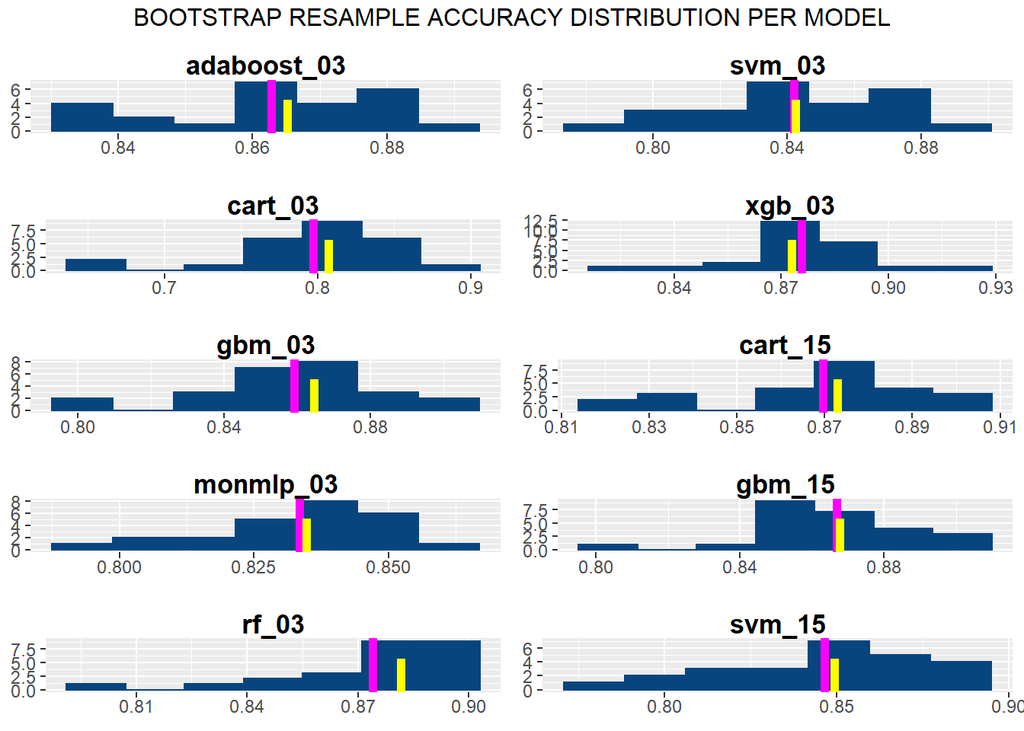

What’s new in comparison with information delivered by predicting on the whole training set? Generally speaking, accuracy level has decreased, sometimes dramatically. This was expected.

Some of these empirical distributions are left-skewed and some are right-skewed.

To further evaluate the merits of the remaining models, let’s produce a comparative table.

| ID | Min. | 1st Qu. | Median | Mean | 3rd Qu. | Max. |
| --- | --- | --- | --- | --- | --- | --- |
| adaboost_03 | 0.8313 | 0.8559 | 0.8652 | 0.8627 | 0.8764 | 0.8857 |
| cart_15 | 0.8266 | 0.8623 | 0.8729 | 0.8696 | 0.8816 | 0.9073 |
| xgb_03 | 0.8204 | 0.8655 | 0.8729 | 0.8757 | 0.8867 | 0.9174 |
| gbm_03 | 0.8065 | 0.8449 | 0.8645 | 0.8591 | 0.8745 | 0.9066 |
| gbm_15 | 0.8024 | 0.8566 | 0.8678 | 0.8669 | 0.8785 | 0.9008 |
| rf_03 | 0.8008 | 0.8708 | 0.8816 | 0.8739 | 0.8884 | 0.8967 |
| monmlp_03 | 0.7957 | 0.8263 | 0.8346 | 0.8334 | 0.8468 | 0.8636 |
| svm_15 | 0.7878 | 0.8292 | 0.8492 | 0.8463 | 0.8678 | 0.8941 |
| svm_03 | 0.7849 | 0.8193 | 0.8425 | 0.8420 | 0.8672 | 0.8941 |
| cart_03 | 0.6490 | 0.7773 | 0.8072 | 0.7971 | 0.8306 | 0.8803 |

xgb_03 is the model selected to get validated on the validation set.

## VIII. RESULTS on the VALIDATION SET

### A. Constructing the Validation Set

In order to predict on the validation set, the training set and the validation set have to contain the same columns, i.e. the same labels (dependent variable) and the same predictors. For labels, there is no problem. Let’s see about predictors.

The training set already exists, it is sentSparse_av2, which has been built up through NLP and with text mining insights (negational unigrams integrated and generic tokens replacing sentiment polarized tokens). The training set cannot be changed to match the validation set since this would imply, in one way or another, retrieving some information from the validation and instilling it into the training set, which is contrary with the very status of a validation set.

The validation set will be constructed in the same way as the training set, but independently: NLP, negational unigrams and polarization. Columns from the validation set will be aligned on the training set, of course not in content but in headers, in column names (i.e. in tokens). Columns that are in the validation set but not in the training set will be removed. Columns that are in the training set but not in the validation set will be added as null vectors to the validation set.

### B. Predicting on the Validation Set

The xgb_03 model can now be validated on the validation set: predictions will be computed on the validation set and then accuracy.

|  | ACCURACY ON THE VALIDATION SET |
| --- | --- |
| Baseline Model | 0.5000 |
| Final Model: NLP + Text Mining + XGBoost + Default Tuning | 0.9157 |

### C. Attributing Accuracy Improvement per Methodological Layer

Where does the improvement come from? From which step in the whole process: NLP, text mining or machine learning optimization? Splitting contribution to results needs to be done on the validation set since results on the training set can be boosted by overfitting. To evaluate input from each layer, a simple approach will we followed.

On the validation set without polarization and without negation, prediction will be conducted and accuracy produced. The method will be cart_15, i.e. CART with 15-value tuning and 25 bootstrapped resamples: this model is rather fast and can be considered as a yardstick, having proved resilient although not optimal. This will help evaluate the impact of NLP.

Then, on the validation set with negation, a second evaluation will be conducted with cart_15: this will help evaluate the impact of integrating negation.

On the validation set with negation and polarization, a third evaluation will be conducted with cart_15: this will help evaluate the impact of polarization.

The accuracy difference between this last result and the result from eXtreme Gradient Boosting will measure the impact of machine learning optimization.

| METHODOLOGY | ACCURACY ON THE VALIDATION SET |
| --- | --- |
| Baseline Model | 0.5000 |
| NLP + cart_15 | 0.7169 |
| NLP + Negation + cart_15 | 0.7349 |
| NLP + Negation + Polarization + cart_15 | 0.8675 |
| NLP + Negation + Polarization + xgb_03 | 0.9157 |

**Natural Language Processing** has contributed 21.7 percentage points.

## IX. SUMMARY & CONCLUSION

The Executive Summary, at the very beginning of this document, provides a nice overview. A dynamic table of content allows easy access to more detailed information.

In particular, the main insights from text mining can be found in “VI. INFORMATION RETRIEVAL USING INSIGHTS, C. Polarization - Text Classification - Text Substitution”. Instead of using existing dictionaries, customized lists of polarized tokens have been established from perusing unused subjective information available in false negatives and false positives. In reviews, instances matching these polarized tokens have been replaced by a generic token either positive or negative, boosting use of subjective information.

Dear Readers,

Thank you for reaching the end. Please don’t hesitate to get in touch with me through my GitHub email address. I am interested in all kinds of comments.

## X. REFERENCES

Availability has been checked up on March 30, 2020.

### A. Sentiment Analysis

https://www.edx.org/course/the-analytics-edge

https://www.tidytextmining.com/sentiment.html

https://medium.com/@annabiancajones/sentiment-analysis-of-reviews-text-pre-processing-6359343784fb

https://cran.r-project.org/web/packages/SentimentAnalysis/vignettes/SentimentAnalysis.html

https://monkeylearn.com/sentiment-analysis/

https://towardsdatascience.com/basic-binary-sentiment-analysis-using-nltk-c94ba17ae386

https://medium.com/@datamonsters/sentiment-analysis-tools-overview-part-1-positive-and-negative-words-databases-ae35431a470c

### B. Text Mining

https://www.tidytextmining.com/tidytext.html

https://monkeylearn.com/text-mining/

### C. About Resample Distribution of Accuracy

https://books.google.be/books?id=GgmqDwAAQBAJ&pg=PA80&lpg=PA80&dq#v=onepage&q&f=false

https://www.edx.org/course/data-science-machine-learning

### D. Something Simple about Overfitting

https://www.r-bloggers.com/machine-learning-explained-overfitting/

# *********************************************************************************

# *********************************************************************************